# Project 2, Phase 3

RafaĹ‚ Cylwa

12 czerwca 2016

# Introduction

The aim of our work presented in this report is to predict a number of new breast cancer (BRCA) cases for each combination of age/gender/TERYT4 for the next year based on data from years 2010-2012. We expaded the given data set by some additional variables that might be related to breast cancer such as pollution rates, birth rates per region, average salary in region, number of people in production age etc. downloaded from Bank Danych Lokalnych GUS.

To assess the performance of considered models we used the validation set approach. Years 2010 and 2011 were used for training the models and 2012 was used for testing (calculating MSE).

Among all models we chose the XGBoost algorithm as the one that gives best predictions measured by MSE on the test set.

# The data

We load some packages used in our analysis and the data, which we previously prepared (this included mainly merging data from different sources and adding observations for all combinations of year, TERYT4, gender and age group).

```r
library(glmnet) # generalized linear models
library(xgboost) # boosting
library(lme4) # estimation of mixed models
library(Matrix) # enables us to create a data matrix with factor variables turned into binary ones
library(MASS) # estimation of the negative binomial model
library(pscl) # estimation of the zero-inflated Poisson regression
library(randomForest) # random forests
library(Ckmeans.1d.dp) # plotting variables importance for boosting
library(ggplot2) # plotting
library(reshape2) # data transformation
library(data.table)
setwd("~/UniwersytetWarszawski/Statistics/Project2")
load("Faza3_dane.rda")
data1 <- data1[,-c(6:12,18:19,21:26)] # we remove some variables, that are not used in this analysis
data1$TERYT4 <- as.factor(data1$TERYT4) # the code of the county should be a factor
```

Our dependent variable will always be `nowy`. The main potential regressors in our dataset include gender, age group and indicator of a city-county. As we predict the (non-scaled) number of breast cancer cases per gender/age group/county combination we need to add some measure of population of the county. Also, to the best of our knowledge, pollution can increase the risk of breast cancer. Also, prophylaxix and regular check-ups are important to prevent development of breast cancer: due to lack of appropriate data concerning health care we include the mean wage as some measure of economic development that could potentially capture this effect. Moreover, as breast cancer is connected with reproduction we include the number of live births per 1000 inhabitants. To conclude, we added the following variables to the dataset:

- population of the county: `ludnosc_pow` - total, `mez_pow` - men, `kob_pow` - women, `lud_przedprod` - people under 18 years old (wiek przedprodukcyjny), `lud_prod` - women between 18-59 and men between 18-64 years old (wiek produkcyjny), `lud_poprod` - women over 59 and men over 64 (wiek poprodukcyjny), we will use the direct translation “productive” to name the last three populations,
- industrial pollution in the county (in tonnes): `zanieczyszczenie`,
- air pollution in the voivodeship (in tonnes): `dwutlenek.siarki`, `tlenki.azotu`, `tlenek.węgla`, `dwutlenek.węgla`, `metan`, `podtlenek.azotu`,
- number of live births (per 1000 inhabitants): `urodzenia`,
- mean wage (percentage of country mean): `wynagrodzenie`.

The structure of our dataset is the following:

```r
str(data1)
```

```
## 'data.frame':    13644 obs. of  23 variables:
##  $ TERYT4          : Factor w/ 379 levels "201","202","203",..: 91 91 91 91 91 91 91 91 91 91 ...
##  $ rok             : num  2010 2010 2010 2010 2010 2010 2010 2010 2010 2010 ...
##  $ wojewodztwo     : Factor w/ 16 levels "dolnośląskie",..: 5 5 5 5 5 5 5 5 5 5 ...
##  $ PLEC            : Factor w/ 2 levels "K","M": 1 1 1 1 1 1 2 2 2 2 ...
##  $ grupa_wiek      : Factor w/ 6 levels "<0-44>","<45-54>",..: 1 2 3 4 5 6 1 2 3 4 ...
##  $ powiat          : chr  "bełchatowski" "bełchatowski" "bełchatowski" "bełchatowski" ...
##  $ ludnosc_pow     : num  113000 113000 113000 113000 113000 113000 113000 113000 113000 113000 ...
##  $ mez_pow         : num  55615 55615 55615 55615 55615 ...
##  $ kob_pow         : num  57385 57385 57385 57385 57385 ...
##  $ zanieczyszczenia: num  30201464 30201464 30201464 30201464 30201464 ...
##  $ miasto          : num  0 0 0 0 0 0 0 0 0 0 ...
##  $ nowy            : num  8 17 14 7 3 0 0 0 1 0 ...
##  $ dwutlenek.siarki: num  92321 92321 92321 92321 92321 ...
##  $ tlenki.azotu    : num  52862 52862 52862 52862 52862 ...
##  $ tlenek.węgla    : num  22772 22772 22772 22772 22772 ...
##  $ dwutlenek.węgla : num  39768849 39768849 39768849 39768849 39768849 ...
##  $ metan           : num  4 4 4 4 4 4 4 4 4 4 ...
##  $ podtlenek.azotu : num  7 7 7 7 7 7 7 7 7 7 ...
##  $ wynagrodzenie   : num  135 135 135 135 135 ...
##  $ urodzenia       : num  11.8 11.8 11.8 11.8 11.8 11.8 11.8 11.8 11.8 11.8 ...
##  $ lud_przedprod   : num  21535 21535 21535 21535 21535 ...
##  $ lud_prod        : num  77056 77056 77056 77056 77056 ...
##  $ lud_poprod      : num  14447 14447 14447 14447 14447 ...
```

In order to asses the forecasting ability of the models we consider, we divide our dataset into the training set (observations for years 2010 and 2011) and test set (observations for year 2012).

```r
train <- data1[data1$rok != 2012,]
test <- data1[data1$rok == 2012,]
```

After selecting the best of our models we will perform a prediction for year 2013 for which we only have the independent variables so this will be our true prediction.

```r
load("dane_2013.rda")
```

# Model selection

In this section we will consider three types of models: linear regression, regression for count data and tree-based models. As our main goal is to predict the number of breast cancer cases in 2013 we will compare all models on the basis of their MSE on the test set (year 2012). However, we will also consider the information criteria (where possible), whether a model differentiates the counties geographically, how many parameters do we need to estimate and which variables have a significant impact on the dependent one. For some models, we will additionally look at the residuals, distribution of predictions and distribution of the MSE on repeatedly drawn bootstrap samples of the test set.

We will use the following functions to calculate the mean-squared error: `mse()` for default predictions ald `mseR()` for response-type predictions (useful for example for Poisson regression). Both functions return the MSE and predicted values.

```r
mse <- function(model){
    return(list(mean((predict(model, newdata = test) - test$nowy)^2), predict(model, newdata = test)))
}

mseR <- function(model){
    return(list(mean((predict(model, newdata = test, type = "response")-test$nowy)^2), predict(model, newdata = test, type = "response")))
}
```

## Linear models

Our first attempt was to fit a linear model. First we fit a model with all variables, excluding some that are perfectly collinear: for example we included the population of men, women and population of “productive” and “older than productive” as we consider the “younger than productive” less relevant for breast cancer which affects mostly older people. Also, we cannot include county-indicators as there is not enough observations to estimate constants separately for each county so we only include voivodeship-indicators.

We start with a regular least squares regression and after estimating the full model perform stepwise selection using the AIC and BIC criteria.

```r
model_lm_full <- lm(nowy ~ rok + PLEC + grupa_wiek + mez_pow + kob_pow + zanieczyszczenia + miasto + wynagrodzenie + urodzenia + lud_poprod + lud_prod + dwutlenek.siarki + tlenki.azotu + tlenek.węgla + dwutlenek.węgla + metan + podtlenek.azotu + wojewodztwo, data = train)

model_lm_AIC <- step(model_lm_full, direction="both", k=2, trace=FALSE)
summary(model_lm_AIC)
```

```
##
## Call:
## lm(formula = nowy ~ PLEC + grupa_wiek + mez_pow + urodzenia +
##     lud_poprod + lud_prod + podtlenek.azotu, data = train)
##
## Residuals:
##      Min       1Q   Median       3Q      Max
## -100.610   -2.743   -0.446    2.402  279.118
##
## Coefficients:
##                     Estimate Std. Error t value Pr(>|t|)
## (Intercept)        6.698e-01  9.048e-01   0.740   0.4592
## PLECM             -8.135e+00  1.960e-01 -41.500  < 2e-16 ***
## grupa_wiek<45-54>  3.020e+00  3.395e-01   8.896  < 2e-16 ***
## grupa_wiek<55-64>  5.924e+00  3.395e-01  17.447  < 2e-16 ***
## grupa_wiek<65-74>  2.493e+00  3.395e-01   7.342 2.29e-13 ***
## grupa_wiek<75-84>  5.300e-01  3.395e-01   1.561   0.1186
## grupa_wiek85+     -1.929e+00  3.395e-01  -5.682 1.38e-08 ***
## mez_pow           -3.522e-04  6.284e-05  -5.604 2.15e-08 ***
## urodzenia          1.776e-01  8.892e-02   1.998   0.0458 *
## lud_poprod         2.850e-04  3.272e-05   8.710  < 2e-16 ***
## lud_prod           2.548e-04  4.656e-05   5.472 4.57e-08 ***
## podtlenek.azotu   -2.812e-04  1.743e-04  -1.614   0.1066
## ---
## Signif. codes:  0 '***' 0.001 '**' 0.01 '*' 0.05 '.' 0.1 ' ' 1
##
## Residual standard error: 9.348 on 9084 degrees of freedom
## Multiple R-squared:  0.4492, Adjusted R-squared:  0.4486
## F-statistic: 673.5 on 11 and 9084 DF,  p-value: < 2.2e-16
```

The above result comes from stepwise selection according to AIC. As we can see the variables concerning voivodeship, industrial pollution and all air pollution measures except `podtlenek.azotu` were removed from the model. We can see that the model predicts less instances of breast cancer for men than for women and more for every age group except “85+” in comparison to the reference “<0,44>” (the difference for “<75-84>” is insignificant). Moreover, the number of men, people in “productive” and older than “productive” age in the county are significant when it comes to determining the number of breast cancer cases. The number of live births is significant only at 5% significance level and `podtlenek.azotu` is not but remains in the model.

```r
model_lm_BIC <- step(model_lm_full, direction="both", k=log(nrow(train)), trace=FALSE)
summary(model_lm_BIC)
```

```
##
## Call:
## lm(formula = nowy ~ PLEC + grupa_wiek + mez_pow + lud_poprod +
##     lud_prod, data = train)
##
## Residuals:
##     Min      1Q  Median      3Q     Max
## -99.876  -2.746  -0.476   2.404 280.089
##
## Coefficients:
##                     Estimate Std. Error t value Pr(>|t|)
## (Intercept)        2.304e+00  3.143e-01   7.330 2.50e-13 ***
## PLECM             -8.135e+00  1.961e-01 -41.490  < 2e-16 ***
## grupa_wiek<45-54>  3.020e+00  3.396e-01   8.894  < 2e-16 ***
## grupa_wiek<55-64>  5.924e+00  3.396e-01  17.442  < 2e-16 ***
## grupa_wiek<65-74>  2.493e+00  3.396e-01   7.340 2.32e-13 ***
## grupa_wiek<75-84>  5.300e-01  3.396e-01   1.561    0.119
## grupa_wiek85+     -1.929e+00  3.396e-01  -5.680 1.39e-08 ***
## mez_pow           -3.522e-04  5.901e-05  -5.968 2.49e-09 ***
## lud_poprod         2.561e-04  2.976e-05   8.606  < 2e-16 ***
## lud_prod           2.638e-04  4.457e-05   5.919 3.36e-09 ***
## ---
## Signif. codes:  0 '***' 0.001 '**' 0.01 '*' 0.05 '.' 0.1 ' ' 1
##
## Residual standard error: 9.35 on 9086 degrees of freedom
## Multiple R-squared:  0.4488, Adjusted R-squared:  0.4483
## F-statistic: 822.1 on 9 and 9086 DF,  p-value: < 2.2e-16
```

The above result comes from stepwise selection according to BIC and differs only slightly from the one selected with AIC: it does not include the variables `urodzenia` and `podtlenek.azotu`. The adjusted R-squared drops only from 0.449 to 0.448 when removing these two variables. When it comes to MSE the three models differed only slightly:

```r
cbind(c("Full model", "Selected with AIC", "Selected with BIC"),rbind(mse(model_lm_full)[[1]], mse(model_lm_AIC)[[1]], mse(model_lm_BIC)[[1]]))
```

```
##      [,1]                [,2]
## [1,] "Full model"        "81.9649790559466"
## [2,] "Selected with AIC" "81.9772423611503"
## [3,] "Selected with BIC" "82.0533245136293"
```

The above MSEs will be more useful for comparison with other models later on. We can also take a look at the plot of predicted values on the x axis and the corresponding observed values on the y axis. To asses the accuracy of predictions we also add a 45-degree line on which all points would be if the predictions were perfect.

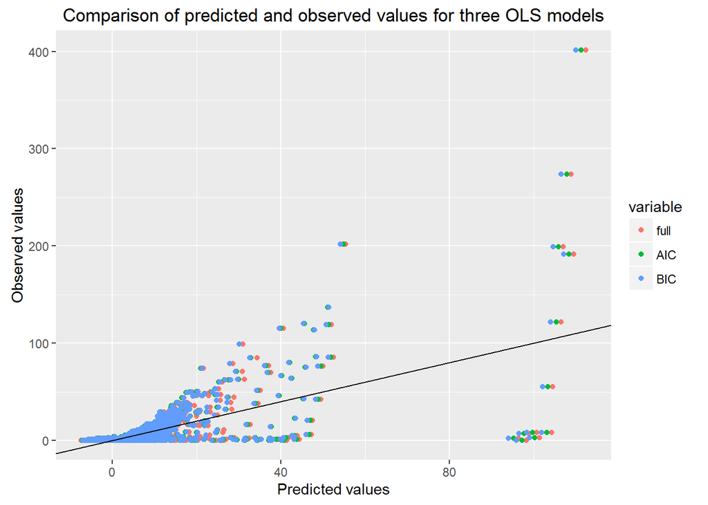

```r
pred_wykres <- data.frame(id = 1:nrow(test), full = mse(model_lm_full)[[2]], AIC = mse(model_lm_AIC)[[2]], BIC = mse(model_lm_BIC)[[2]], nowy = test$nowy)

pred_wykres <- melt(pred_wykres, id.vars = c("id", "nowy"))
ggplot(pred_wykres, aes(x = value, y = nowy, color = variable)) + geom_point() + geom_abline(slope = 1, intercept = 0) + xlab("Predicted values") + ylab("Observed values") + ggtitle("Comparison of predicted and observed values for three OLS models")
```

The above plot shows that the predicted values are very similar across these three linear models and actually very poor: the points are not even concentrated around the 45-degree line: these results are not satisfsctory so now we will try some shrinkage methods (they require transforming the factor variables into binary ones and this is what we do). We would like to note, that in most of the subsequent models we do not include air pollution variables as data for them are only available for voivodeships so including them restricts the number of voivodeship dummies we can include due to colllinearity.

We start with ridge regression: by performing k-fold crossvalidation we choose the best lambda parameter, which turns out to be equal to:

```r
x <- model.matrix(lm(nowy ~., data = subset(data1, select = -c(TERYT4, powiat, ludnosc_pow, lud_przedprod, metan, tlenki.azotu, tlenek.węgla, dwutlenek.węgla, dwutlenek.siarki, podtlenek.azotu))))

indeks <- data1$rok < 2012

x_train <- x[indeks, ]; y_train <- data1[indeks, "nowy"]
x_test <- x[!indeks, ]; y_test <- data1[!indeks, "nowy"]

model_ridge <- cv.glmnet(x_train, y_train, alpha = 0)
(bestlam <- model_ridge$lambda.min) # best lambda
```

```
## [1] 0.7599995
```

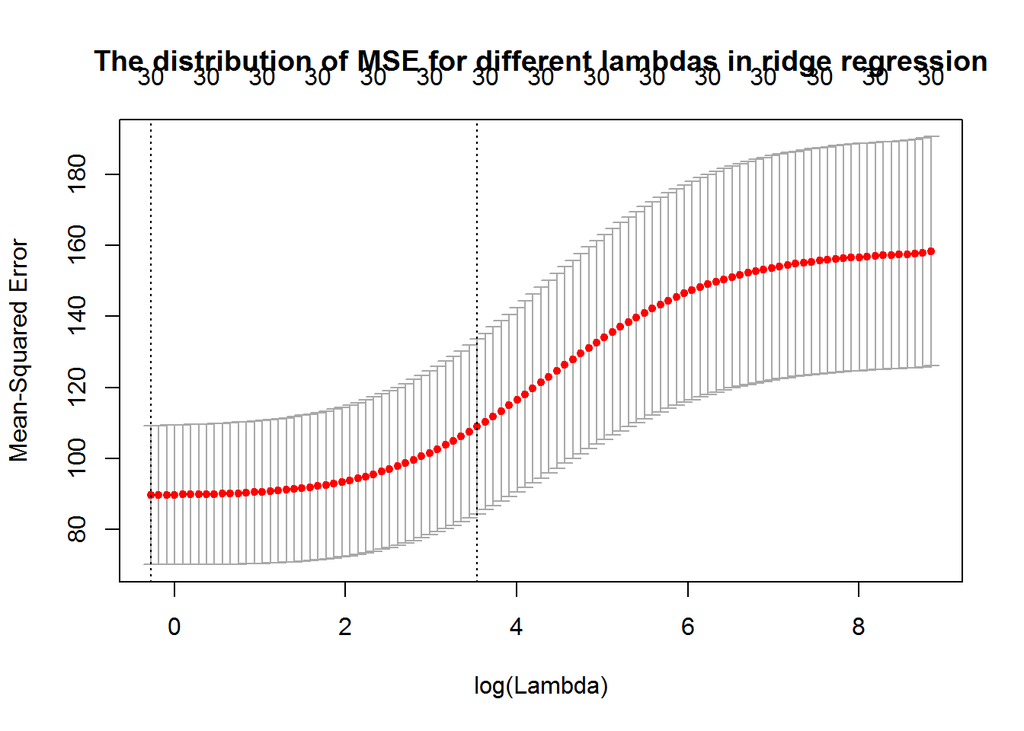

```r
plot(model_ridge, main = "The distribution of MSE for different lambdas in ridge regression") # results of cross-validation
```

The above plot shows the distribution of MSEs depending on the value of lambda - we can see that the MSEs are usually greater than for the linear regression. The MSE asociated with this model is:

```r
mean((predict(model_ridge, s=bestlam, newx=x_test) - y_test)^2)
```

```
## [1] 82.43029
```

This does not improve upon the results of the three linear regressions considered before. Moreover, ridge regression requires estimating parameters for all potential independent variables (does not exclude the irrelevant ones), which leads to loss of precision.

By changing the alpha parameter from 0 to 1 we obtain the lasso regression, which shrinks some coefficients to zero. Similarly as before, we use crossvalidation to select the lambda parameter:

```r
model_lasso <- cv.glmnet(x_train, y_train, alpha = 1)

(bestlam <- model_lasso$lambda.min) # best lambda
```

```
## [1] 0.02375542
```

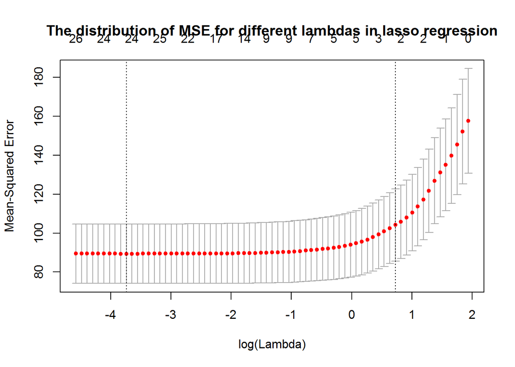

```r
plot(model_lasso, main = "The distribution of MSE for different lambdas in lasso regression") # results of cross-validation
```

Above we see, that for a big range of possible values of lambda the distribution of MSE does not change and then it rapidly grows for bigger lambdas. The MSE of the selected model is:

```r
mean((predict(model_lasso, s = bestlam, newx = x_test) - y_test)^2)
```

```
## [1] 82.03777
```

```r
coef(model_lasso)
```

```
## 32 x 1 sparse Matrix of class "dgCMatrix"
##                                            1
## (Intercept)                     2.7795694239
## (Intercept)                     .
## rok                             .
## wojewodztwokujawsko-pomorskie   .
## wojewodztwolubelskie            .
## wojewodztwolubuskie             .
## wojewodztwołódzkie              .
## wojewodztwomałopolskie          .
## wojewodztwomazowieckie          .
## wojewodztwoopolskie             .
## wojewodztwopodkarpackie         .
## wojewodztwopodlaskie            .
## wojewodztwopomorskie            .
## wojewodztwośląskie              .
## wojewodztwoświętokrzyskie       .
## wojewodztwowarmińsko-mazurskie  .
## wojewodztwowielkopolskie        .
## wojewodztwozachodniopomorskie   .
## PLECM                          -4.0030828379
## grupa_wiek<45-54>               .
## grupa_wiek<55-64>               .
## grupa_wiek<65-74>               .
## grupa_wiek<75-84>               .
## grupa_wiek85+                   .
## mez_pow                         .
## kob_pow                         .
## zanieczyszczenia                .
## miasto                          .
## wynagrodzenie                   .
## urodzenia                       .
## lud_prod                        .
## lud_poprod                      0.0002012648
```

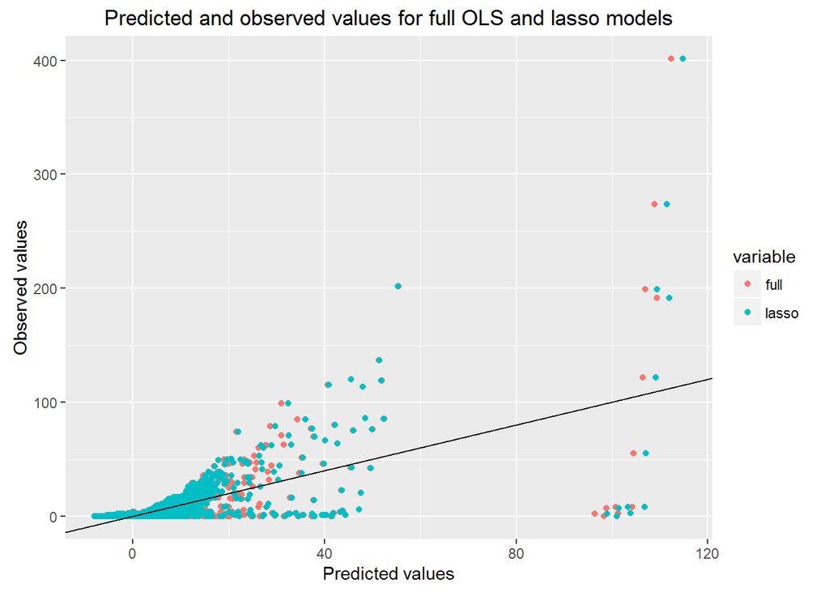

```r
pred_wykres <- data.frame(id = 1:nrow(test), full = mse(model_lm_full)[[2]], lasso = predict(model_lasso, s = bestlam, newx = x_test), nowy = test$nowy)

names(pred_wykres)[3] <- "lasso"
pred_wykres <- melt(pred_wykres, id.vars = c("id", "nowy"))
ggplot(pred_wykres, aes(x = value, y = nowy, color = variable)) + geom_point() + geom_abline(slope = 1, intercept = 0) + xlab("Predicted values") + ylab("Observed values") + ggtitle("Predicted and observed values for full OLS and lasso models")
```

The above plot further confirms that the lasso regression is almost as well fitted as the full model.

So far, we clearly see that fitting linear model does not give us good prediction accuracy. Next we will move to Poisson regression, which is suitable for predicting counts of events.

## Count data models

From a theoretical point of view linear regression is not really appropriate for predicting the number of breast cancer cases as these are count data. Therefore, we include in our analysis the following count-data models:

- Poisson regression (function `glm()`) - we assume that the data follow a Poisson distribution and perform a linear regression for the natural logarythm of the expectation of the Poisson distribution (so that the expectation itself will never be non-positive).
- Negative binomial model (function `glm.nb()`) - this is a generalization of the Poisson regression that accounts for overdispersion, that is, greater observed variance than expectation of the data, which contradicts the assumption that data are Posson-distributed.
- Zero-Inflated Poisson regression (function `zeroinfl()`) - this model allows for a greater number of zeros than Poisson distribution would imply. We assume that some county/gender/age combinations will for sure have zero breast cancer occurences (we predict which using binary regression, for example logistic one) and estimate a Poisson regression for the remaining ones. This approach can be justified by the fact that some county/gender/age combinations can have small populations and therefore very small chance for having any cancer cases at all.
- Poisson regression with random effects (function `glmer()`) - this model finally allows us to properly account for the geographical variability of cancer cases in a Poisson regression framework without estimating too many parameters: we add a random effect for voivodeship and/or county, so that the constant in the Poisson regression has a normal distribution across voivodeships and/or couunties/.

We will compare different models from the above classes and only after selecting the best one among the count data models we interpret its parameters.

It is worth noting, that the values of our dependent variable are not always integer and some (but not all) of the functions we use require integer values. Therefore, we sometimes round the dependent variable or take its floor or ceiling and then compare results, which turn out not to be very sensitive to the type of rounding (each time we report only the best results in terms of MSE of those three approaches).

### Poisson regression

We start with a regular Poisson regression from which we excluded the (insignificant) variable `rok`, which made arguable sense anyway as it implied linear trend across years.

```r
summary(model_poisson <- glm(nowy ~ PLEC + grupa_wiek + mez_pow + lud_prod + lud_poprod + kob_pow + zanieczyszczenia + miasto + wynagrodzenie + urodzenia + wojewodztwo, family="poisson", data = train))
```

```
##
## Call:
## glm(formula = nowy ~ PLEC + grupa_wiek + mez_pow + lud_prod +
##     lud_poprod + kob_pow + zanieczyszczenia + miasto + wynagrodzenie +
##     urodzenia + wojewodztwo, family = "poisson", data = train)
##
## Deviance Residuals:
##     Min       1Q   Median       3Q      Max
## -8.9629  -0.7136  -0.4146   0.2206  15.3604
##
## Coefficients:
##                                  Estimate Std. Error  z value Pr(>|z|)
## (Intercept)                     2.249e+00  7.948e-02   28.291  < 2e-16 ***
## PLECM                          -3.775e+00  3.431e-02 -110.014  < 2e-16 ***
## grupa_wiek<45-54>               7.739e-01  1.931e-02   40.082  < 2e-16 ***
## grupa_wiek<55-64>               1.191e+00  1.824e-02   65.313  < 2e-16 ***
## grupa_wiek<65-74>               6.750e-01  1.962e-02   34.402  < 2e-16 ***
## grupa_wiek<75-84>               1.865e-01  2.161e-02    8.630  < 2e-16 ***
## grupa_wiek85+                  -1.371e+00  3.549e-02  -38.618  < 2e-16 ***
## mez_pow                         2.455e-05  2.859e-06    8.587  < 2e-16 ***
## lud_prod                        2.798e-05  2.894e-06    9.669  < 2e-16 ***
## lud_poprod                     -3.795e-05  3.039e-06  -12.487  < 2e-16 ***
## kob_pow                        -3.427e-05  3.948e-06   -8.681  < 2e-16 ***
## zanieczyszczenia               -2.411e-08  2.460e-09   -9.799  < 2e-16 ***
## miasto                          2.906e-01  1.658e-02   17.527  < 2e-16 ***
## wynagrodzenie                   5.629e-03  4.831e-04   11.651  < 2e-16 ***
## urodzenia                      -1.920e-01  6.449e-03  -29.773  < 2e-16 ***
## wojewodztwokujawsko-pomorskie   1.635e-01  2.977e-02    5.492 3.98e-08 ***
## wojewodztwolubelskie           -4.391e-02  3.115e-02   -1.410 0.158612
## wojewodztwolubuskie            -1.458e-02  3.716e-02   -0.392 0.694816
## wojewodztwołódzkie              5.459e-01  2.761e-02   19.769  < 2e-16 ***
## wojewodztwomałopolskie         -1.397e-02  2.824e-02   -0.495 0.620737
## wojewodztwomazowieckie         -9.120e-02  2.905e-02   -3.140 0.001692 **
## wojewodztwoopolskie            -2.628e-01  3.902e-02   -6.735 1.64e-11 ***
## wojewodztwopodkarpackie        -3.041e-01  3.291e-02   -9.241  < 2e-16 ***
## wojewodztwopodlaskie           -3.916e-01  3.735e-02  -10.485  < 2e-16 ***
## wojewodztwopomorskie            2.812e-01  2.939e-02    9.569  < 2e-16 ***
## wojewodztwośląskie              2.095e-01  2.472e-02    8.475  < 2e-16 ***
## wojewodztwoświętokrzyskie      -1.295e-01  3.638e-02   -3.560 0.000371 ***
## wojewodztwowarmińsko-mazurskie -5.220e-02  3.299e-02   -1.582 0.113590
## wojewodztwowielkopolskie        2.070e-01  2.693e-02    7.686 1.52e-14 ***
## wojewodztwozachodniopomorskie  -1.067e-01  2.963e-02   -3.601 0.000317 ***
## ---
## Signif. codes:  0 '***' 0.001 '**' 0.01 '*' 0.05 '.' 0.1 ' ' 1
##
## (Dispersion parameter for poisson family taken to be 1)
##
##     Null deviance: 105588  on 9095  degrees of freedom
## Residual deviance:  12468  on 9066  degrees of freedom
## AIC: Inf
##
## Number of Fisher Scoring iterations: 6
```

Above we can see that almost all coefficients are significantly different than zero. In particular, most voivodeship dummies are significant and that confirms our intuition that the geographic factor plays a role (we will account for differences between counties in the mixed model later on).

The MSE turns out to be less than half that of the best linear regression:

```r
mseR(model_poisson)[[1]]
```

```
## [1] 40.10229
```

In order to explore the improvement in prediction below we plot the distribution of predicted values of the dependent variable for the Poisson regression and full linear model together with the actual distribution of cancer cases in the test set.

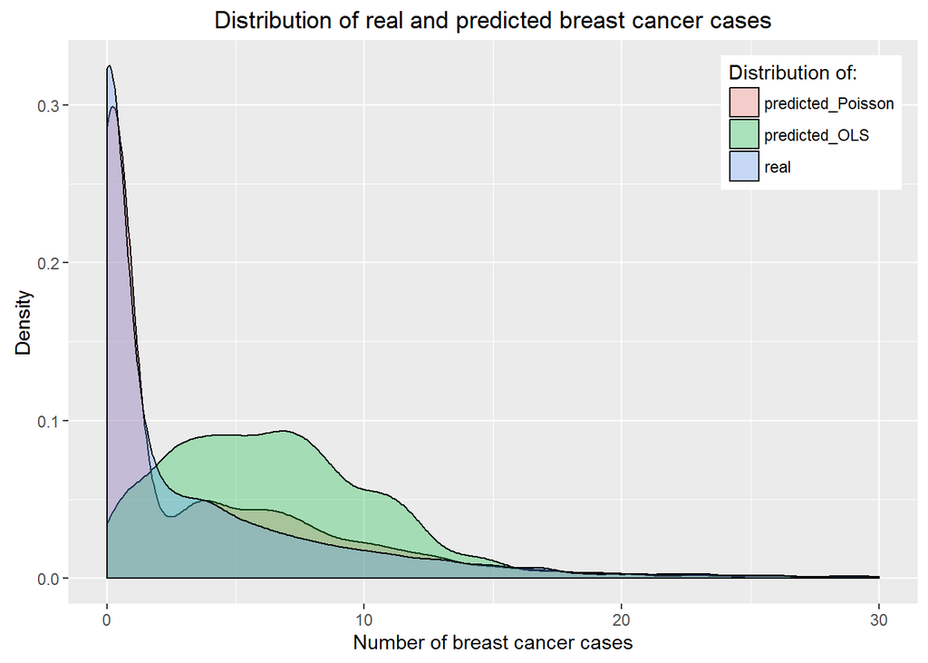

```r
pred_wykres <- data.frame(id = 1:nrow(test), predicted_Poisson = mseR(model_poisson)[[2]], predicted_OLS = mse(model_lm_full)[[2]], real = test$nowy)

pred_wykres <- melt(pred_wykres, id.vars = c("id"))

ggplot(pred_wykres, aes(x=value, fill=variable)) + geom_density(alpha=.3) + xlim(0,30) + xlab("Number of breast cancer cases") + ylab("Density") + theme(legend.justification=c(1,1), legend.position=c(1,1)) + guides(fill=guide_legend(title="Distribution of:", ncol=1)) + ggtitle("Distribution of real and predicted breast cancer cases")
```

As we can see the distribution of predictions of the linear model does not even closely resemble the real distribution of new cancer cases. Clearly, the Poisson model more or less captures the real shape of the distribution so is not only more accurate when it comes to MSE but also when it comes to capturing the properties of the analyzed process (peak for small values etc.).

### Negative binomial model

An obvious generalization of the Poisson regression is the negative binomial model, which allows overdispersion. In order to check if this generalization is justified we perform the likelihood ratio test for overdispersion with the null hypothesis being that Poisson regression is appropriate (i.e. no overdispersion).

```r
model_negbin <- glm.nb(nowy ~ PLEC + grupa_wiek + mez_pow + lud_prod + lud_poprod + kob_pow + zanieczyszczenia + miasto + wynagrodzenie + urodzenia + wojewodztwo, data = train)
odTest(model_negbin , alpha=.05)
```

```
## Likelihood ratio test of H0: Poisson, as restricted NB model:
## n.b., the distribution of the test-statistic under H0 is non-standard
## e.g., see help(odTest) for details/references
##
## Critical value of test statistic at the alpha= 0.05 level: 2.7055
## Chi-Square Test Statistic =  Inf p-value = < 2.2e-16
```

```r
mseR(model_negbin)[[1]]
```

```
## [1] 61.03201
```

As we can see at any usual level of significance we reject the null hypothesis, so the generalization is justified. The estimates in this case are similar, but `lud_prod` and more voivodeship dummies than before are insignificant. However, the MSE is 50% higher than for the Poisson regression and increases even further if we remove `lud_prod` or `wojewodztwo` from the model. Clearly, this model is theoretically better (no crucial assumptions violated) but not when it comes to prediction.

### Zero-inflated models

Another generalization of the Poisson regression that might be of use here is the zero-inflated Poisson regression which includes a binary regression deciding whether an observation should be included into the Poisson estimation or assigned zero right away. Below we see, that almost half of the observations in the training set have value zero of the dependent variable, so the zero-inflated model seems justified.

```r
table(train$nowy == 0)
```

```
##
## FALSE  TRUE
##  4800  4296
```

Before proceeding we scale both our test and train datasets - otherwise the function `zeroinfl()` does not report standard errors and p-values. We try the formula below including different variables (both in the binary regression and the Poisson one we exclude some insignificant ones), with different types of rounding of the dependent variable and different link functions in the binary regression (“logit” or “probit” - in this case the latter performed better). The one reported here is the best we have got when it comes to MSE on the test set:

```r
train2 <- train; train2[,-c(1,3:6,11:12)] <- scale(train2[,-c(1,3:6,11:12)])
test2 <- test; test2[,-c(1,3:6,11:12)] <- scale(test2[,-c(1,3:6,11:12)])
model_poisson0 <- zeroinfl(round(nowy) ~ PLEC + grupa_wiek + mez_pow + lud_prod + lud_poprod + kob_pow + zanieczyszczenia + miasto + wynagrodzenie + urodzenia + wojewodztwo | PLEC + grupa_wiek + mez_pow + lud_prod + lud_poprod + kob_pow + wojewodztwo, data = train2, dist = "poisson", link = "probit", model = TRUE)
mean((predict(model_poisson0, newdata = test2, type = "response")-test2$nowy)^2) # MSE of the above model
```

```
## [1] 30.97314
```

As we can see the MSE is much lower in this case than before. Interestingly, if we ignore the fact, that standard errors and p-values become NA’s returning to the original dataset (i.e. not scaling) allows us to even further reduce the MSE by estimating a much sparser model (removing variables in the model with scaling does not help as here):

```r
model_poisson0 <- zeroinfl(round(nowy) ~ PLEC + grupa_wiek + mez_pow + lud_poprod + kob_pow + miasto + wynagrodzenie | mez_pow + lud_poprod + kob_pow, data = train, dist = "poisson", link = "probit", model = TRUE)
mseR(model_poisson0)[[1]]
```

```
## [1] 27.45039
```

Therefore, again, the theoretically better model (without problems with estimation of SE and p-values) performs worse when it comes to predictions on the test set. It is worth noting, that the above model estimated on the scaled dataset gives MSE of 37.47 (and some variables insignificant), so much worse. Below we also estimate similar zero-inflated negative binomial models that appear to be terrible when it comes to predictions so we do not pursue this further.

```r
model_negbin0 <- zeroinfl(round(nowy) ~ PLEC + grupa_wiek + mez_pow + lud_prod + lud_poprod + kob_pow + zanieczyszczenia + miasto + wynagrodzenie + urodzenia + wojewodztwo | PLEC + grupa_wiek + mez_pow + lud_prod + lud_poprod + kob_pow + wojewodztwo, data = train2, dist = "negbin", link = "probit", model = TRUE)
mean((predict(model_negbin0, newdata = test2, type = "response")-test2$nowy)^2)
```

```
## [1] 725.7388
```

```r
model_negbin0 <- zeroinfl(round(nowy) ~ PLEC + grupa_wiek + mez_pow + lud_poprod + kob_pow + miasto + wynagrodzenie | mez_pow + lud_poprod + kob_pow, data = train, dist = "negbin", link = "probit", model = TRUE)
mseR(model_negbin0)[[1]]
```

```
## [1] 1298.157
```

### Mixed effects Poisson regression

Up to this point the only way we accounted for the geographical variability of breast cancer cases was by adding voivodeship dummies. This is clearly not the best we can do as the data concern counties so we can expect differences between them. As estimating an intercept for each county would be highly imprecise (due to small number of observations for each county) we can assume they are normally distributed with mean zero (and leave a common intercept) and estimate their variance. That is exactly what we do here by adding random effects for voivodeship and/or county to the Poisson regression model.

First, we simply add a random intercept for counties to the basic Poisson model we started with. In order to estimate this model we had to remove a few variables due to some convergence issues. After trying out a few different models we came up with the best one when it comes to MSE:

```r
model_mix_county <- glmer(round(nowy) ~ 1 + (1 | TERYT4) + PLEC + grupa_wiek + mez_pow + kob_pow + miasto + wynagrodzenie + urodzenia, data = train, family = poisson(link = "log"))
mseR(model_mix_county)[[1]]
```

```
## [1] 8.3429
```

Apart from the random effect among counties we could also add one for voivodeships having in mind that this is a hierarchical structure: each county belongs to exactly one voivodeship. This leads us to the following MSE:

```r
model_mix_voivod <- glmer(round(nowy) ~ 1 + (1 | wojewodztwo) + (1 | wojewodztwo:TERYT4) + PLEC + grupa_wiek + mez_pow + kob_pow + miasto + wynagrodzenie + urodzenia, data = train, family = poisson(link = "log"))
mseR(model_mix_voivod)[[1]]
```

```
## [1] 8.399878
```

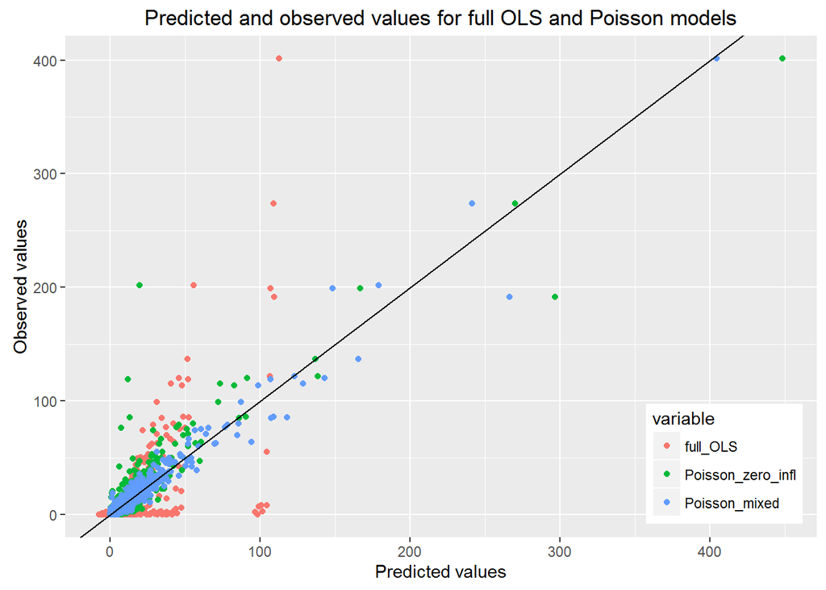

```r
pred_wykres <- data.frame(id = 1:nrow(test), full_OLS = mse(model_lm_full)[[2]], real = test$nowy, Poisson_zero_infl = mseR(model_poisson0)[[2]], Poisson_mixed = mseR(model_mix_county)[[2]])

pred_wykres <- melt(pred_wykres, id.vars = c("id", "real"))

ggplot(pred_wykres, aes(x = value, y = real, color = variable)) + geom_point() + geom_abline(slope = 1, intercept = 0) + xlab("Predicted values") + ylab("Observed values") + ggtitle("Predicted and observed values for full OLS and Poisson models") + theme(legend.justification=c(1,0), legend.position=c(1,0))
```

```r
temp <- train
logLikelihood <- logLik(model_mix_county)
set.seed(1)

logLikSubregions <- replicate(50, {
      temp$TERYT4 <- sample(temp$TERYT4)
      tmp <-  glmer(round(nowy) ~ 1 + (1 | TERYT4) + PLEC + grupa_wiek + mez_pow + kob_pow + miasto + wynagrodzenie + urodzenia, data = train, family = poisson(link = "log"))
      logLik(tmp)
})

mean(logLikSubregions > logLikelihood)
```

```
## [1] 0
```

The parameter estimates of the best model so far, that is the mixed Poisson regression, are included below:

```r
summary(model_mix_county)$coefficients
```

```
##                        Estimate   Std. Error     z value      Pr(>|z|)
## (Intercept)        6.631572e-01 1.746709e-01    3.796609  1.466886e-04
## PLECM             -3.785892e+00 3.443841e-02 -109.932268  0.000000e+00
## grupa_wiek<45-54>  7.728334e-01 1.927211e-02   40.101123  0.000000e+00
## grupa_wiek<55-64>  1.191007e+00 1.820224e-02   65.431901  0.000000e+00
## grupa_wiek<65-74>  6.746921e-01 1.958346e-02   34.452133 4.183629e-260
## grupa_wiek<75-84>  1.862043e-01 2.156439e-02    8.634804  5.882783e-18
## grupa_wiek85+     -1.379104e+00 3.554144e-02  -38.802689  0.000000e+00
## mez_pow            9.340455e-05 2.505243e-06   37.283630 3.023083e-304
## kob_pow           -7.335094e-05 2.163848e-06  -33.898378 7.038446e-252
## miasto             4.919975e-01 5.517472e-02    8.917082  4.787345e-19
## wynagrodzenie      4.714034e-03 1.666501e-03    2.828702  4.673713e-03
## urodzenia         -5.806651e-02 1.019939e-02   -5.693138  1.247258e-08
```

```r
summary(model_mix_county)$AICtab
```

```
##       AIC       BIC    logLik  deviance  df.resid
##  25166.46  25258.96 -12570.23  25140.46   9083.00
```

# Boosting and random forest

Then we analyzed tree-based models: boosting and random forest. We also considered linear-based boosting, but it turned out to behave worse. As in the previous models we included some new variables: air pollution, demographics, etc.

```r
setwd("C:/Users/Agnieszka/Documents/UniwersytetWarszawski/Statistics/Project2")
load("./Faza3_dane.rda")
data1 <- data1[,-c(6:12,18:19,21:26)]
modelMatrix <- model.matrix(lm(nowy ~., subset(data1, select = -c(TERYT4))))
index <- data1$rok < 2012

train <- modelMatrix[index,]
test <- modelMatrix[index == FALSE,]
```

To assess models performance we constructed custom validation. First, we splitted training set into two parts. On the first part, which contained data from years 2010 and 2011, we set model’s parameters. Using data from 2012 we estimated MSE distribution. To do so, we bootstrapped many times from validation set and calculated MSE separately for every bootstrap sample.

```r
rm(mse)

library(Metrics)

mseBoot <- function(model) {
      tmpIndex <- sample(which(index == FALSE), replace = TRUE)
      tmpTest <- modelMatrix[tmpIndex,]
      pred <- predict(model, tmpTest)
      pred <- ifelse(pred < 0, 0, pred)
      mse(data1$nowy[tmpIndex], pred)
}
```

## Random forest

We trained random forest for different number of trees and different numbers of variables used in a one tree. It turned out that the best parameters were 500 and 30, respectively.

```r
#mind that we don't include cross-validation here, as it is computationally expensive...
M <- 100
randForestModel <- randomForest(train,
                                data1$nowy[index], mtry = 30)

predRF <- predict(randForestModel, test)
mseRF <- replicate(M, mseBoot(randForestModel))
```

## Boosting

```r
#data preparation
matrix <- xgb.DMatrix(data = train,
                      label = data1$nowy[index])

param <- list()
```

We started with a model with all variables included.

```r
M <- 100
xgbModelFull <- xgb.train(param, matrix, nrounds = 40)

pred <- predict(xgbModelFull, xgb.DMatrix(data = test))
pred <- ifelse(pred < 0, 0, pred)

mseFull <- replicate(M, mseBoot(xgbModelFull))

predOnTrain <- predict(xgbModelFull, matrix)
```

The full model achieved mean MSE 5.979 on the validation set. Standard deviation of MSE on this set was 0.484. MSE calculated on the test set was 3.609. So we may conclude that the model was overfitted.

We ran cross-validation to set the most suitable number of iteration. MSE distributions for given numbers of interation are presentated in a plot below.

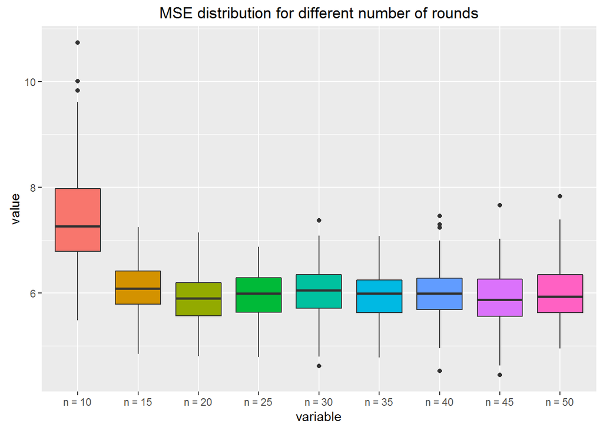

```r
M <- 100
grid <- seq(10, 50, 5)
mseCV <- matrix(NA, ncol = length(grid), nrow = M)

for(nrds in grid) {
      #print(nrds)
      mod <- xgb.train(param, matrix, nrounds = nrds)
      mseCV[, nrds / 5 - 1] <- t(replicate(M, mseBoot(mod)))
}

colnames(mseCV) <- paste0("n = ", grid)
mseCV <- as.data.table(mseCV)
mseCV <- melt(mseCV)

ggplot(mseCV, aes(x = variable, y = value, fill = variable)) + geom_boxplot() + guides(fill = "none") +
      ggtitle("MSE distribution for different number of rounds")
```

We may observe that MSE decreases significantly with adding iterations only at the beginning. We decided on using 30 rounds in our model.

Then we were interested which variables are important in the model. Below we present top 15 most important variables.

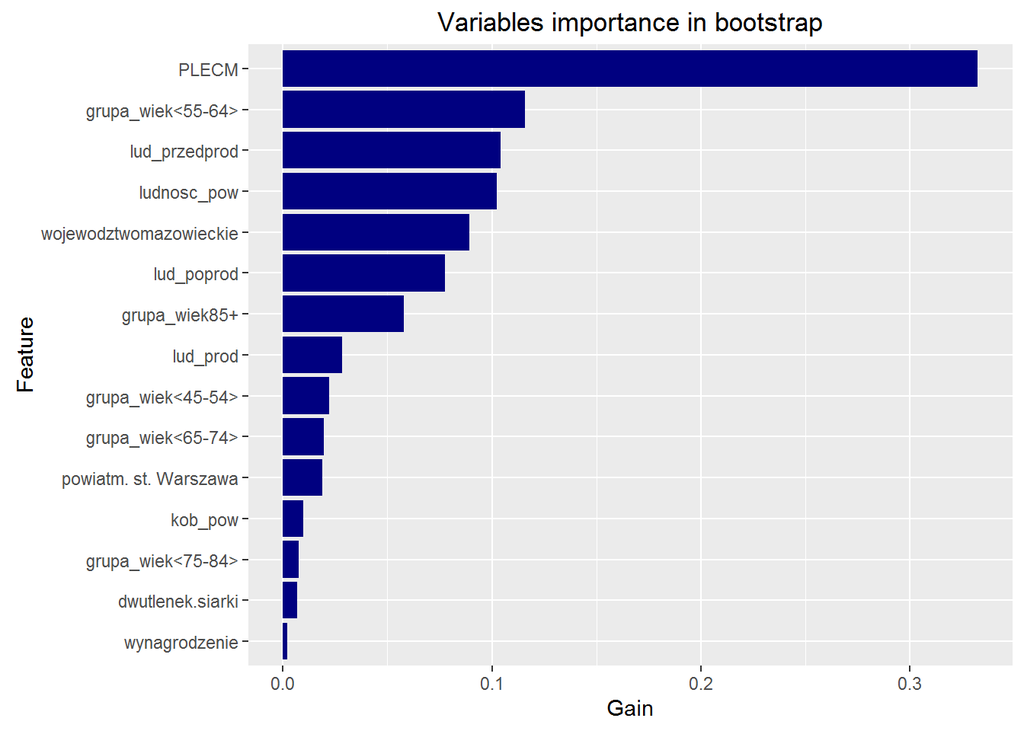

```r
xgbModelFullFinal <- xgb.train(param, matrix, nrounds = 30)

xgbImportance <- xgb.importance(colnames(train),
                                model = xgbModelFullFinal)

library(Ckmeans.1d.dp)
importantVariables <- xgbImportance[1:15,]
importantVariables <- importantVariables[order(Gain),]
importantVariables$Feature <- factor(importantVariables$Feature,
                                     levels = importantVariables$Feature)

ggplot(importantVariables, aes(x = Feature, y = Gain)) + geom_bar(stat = "identity", fill = "navy") + coord_flip() +
      ggtitle("Variables importance in bootstrap")
```

In the feature importance plot presented here we can see that gender and age group are among the most important factors. Moreover, some population variables are very important: total population of the county, population under and over working age, while others like number of women or population in the working age are only slightly important. Among dummies indicating voivodeships and counties two appear to play an important role: the one indicating Mazowieckie voivodeship and the one indicating city of Warsaw.

It is worth noting, that the mean wage appears to be slightly important here, whereas the number of live births per 1000 inhabitants is not – in most of the other models these two were significant. On the other hand, in all our models most pollution (both air and industrial) seems not to influence breast cancer occurrence (the only substance that occured in feature importance plot is sulfar dioxide but it’s gain is not significant).

We ran models excluding some sets of less important variables to see weather this influences positively model performance. We set most suitable number of iteration similarly as before.

```r
setwd("C:/Users/Agnieszka/Documents/UniwersytetWarszawski/Statistics/Project2")
load("./Faza3_dane.rda")
modelMatrix <- model.matrix(lm(nowy ~., data = cbind(subset(data1,
                                                      select = -c(TERYT4, Stage1,
                                                                  Stage2, Stage3,
                                                                  Stage4, ICD10,
                                                                  woj, pow, powiat,
                                                                  nowy_pow, nowy_woj,
                                                                  id, mez_pow, metan,
                                                                  mez_woj, kob_woj, dwutlenek.węgla,
                                                                  tlenek.węgla, podtlenek.azotu,
                                                                  tlenki.azotu, zan_kraj)),
                                                     data1$powiat == "m. st. Warszawa")))

colnames(modelMatrix)[ncol(modelMatrix)] <- "Warszawa"

index <- data1$rok < 2012

train <- modelMatrix[index,]
test <- modelMatrix[index == FALSE,]

matrix <- xgb.DMatrix(data = train,
                      label = data1$nowy[index])

param <- list()
xgbModel <- xgb.train(param, matrix, nrounds = 24)

pred <- predict(xgbModel, xgb.DMatrix(data = test))
```

```r
M <- 100 #20 iteracji pasuje
grid <- seq(10, 50, 5)
mseMean <- vector(mode = "numeric", length = length(grid))

for(nrds in grid) {
      #print(nrds)
      mod <- xgb.train(param, matrix, nrounds = nrds)
      mseMean[nrds] <- mean(replicate(M, mseBoot(mod)))
}

mseMean <- mseMean[!is.na(mseMean) & mseMean > 0]
names(mseMean) <- grid
```

It turned out that removing counties’ dummies and some polutions gave us slightly better results. Models without dummies for voievodships performed worse, so we decided to keep those variables.

```r
M <- 100
xgbModelFinal <- xgb.train(param, matrix, nrounds = 20)
mseFinal <- replicate(M, mseBoot(xgbModelFinal))
```

# Prediction for 2013

At the end we compared tree best models we achieved: boosting, random forest and Poisson regression. The plot before presents distribution of MSE for different models. For the final predictions we chose boosting with 26 predictors and 20 rounds.

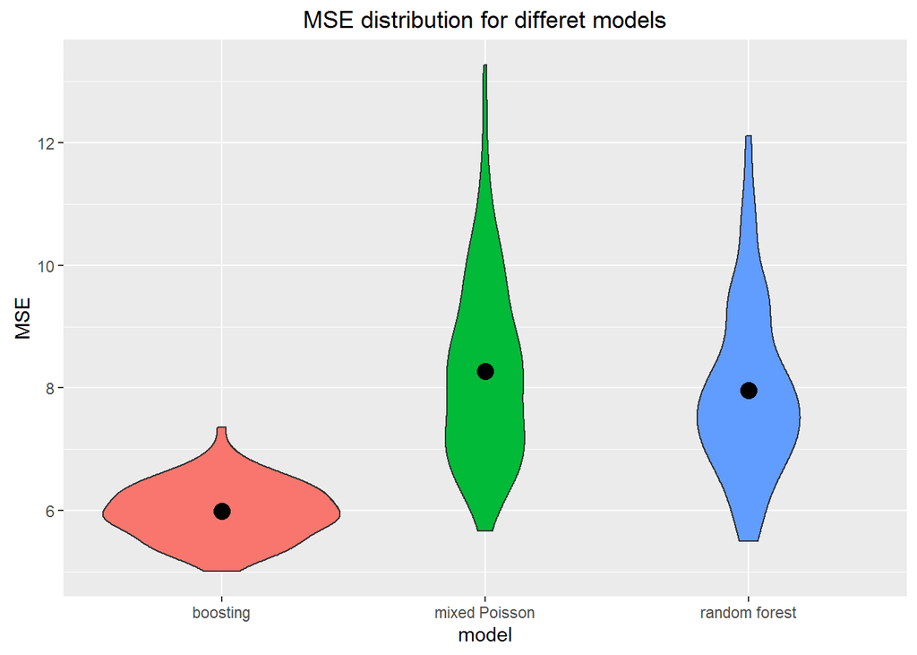

```r
ggplot(wykres, aes(x = model, y = MSE, fill = model)) + geom_violin() + guides(fill = FALSE) +
      ggtitle("MSE distribution for differet models") + stat_summary(fun.y = "mean", geom = "point", size = 4)
```

```r
setwd("C:/Users/Agnieszka/Documents/UniwersytetWarszawski/Statistics/Project2")
library(dplyr)
load("./dane_2013.rda")

grid <- expand.grid(TERYT4 = unique(dane_2013$TERYT4), PLEC = unique(data1$PLEC), grupa_wiek = unique(data1$grupa_wiek))
dane_2013$wojewodztwo <- tolower(dane_2013$wojewodztwo)
dane <- left_join(grid, dane_2013)
colnames(dane)[23:25] <- c("lud_przedprod", "lud_prod", "lud_poprod")


modelMatrixPred <- model.matrix(lm(TERYT4 ~., data = cbind(subset(dane, select = -c(powiat, mez_pow,
                                                                              metan, mez_woj, kob_woj,
                                                                              dwutlenek.wegla, tlenek.wegla,
                                                                              podtlenek.azotu, tlenki.azotu,
                                                                              zan_kraj)),
                                                           dane$powiat == "m. st. Warszawa")))

colnames(modelMatrixPred)[ncol(modelMatrixPred)] <- "Warszawa"

modelMatrixPred <- modelMatrixPred[, colnames(modelMatrix)]

predictions <- predict(xgbModelFinal, xgb.DMatrix(data = modelMatrixPred))
predictions <- cbind(grid, ifelse(predictions > 0, predictions, 0))
colnames(predictions) <- c("TERYT_CODE", "gender", "age", "predicted_BRCA_cases")
write.csv(predictions, file = "./RC_AD_AP_AS_predictions.csv", row.names = FALSE)
```